# DATA SoSe 2025 Tag 3

Ahrabhi Kathirgamalingam

2025-07-24

## Daten und Packages importieren

1. Packages installieren und/ oder aktivieren: rio und tidyverse
2. Import der ALLBUS 2018 Daten

```r
setwd("/Users/ahrabhi.kathirgamalingam/Documents/03_LEHRE/HHU/DATA HHU/SoSe_2025/data")
library(rio)
library(tidyverse)

allbus <- import("ALLBUS2018Komplett.sav")
```

3. In einem neuem Dataframe werden die Variablen pt01 bis pt20 gespeichert. Nutzt dafür den Befehl select() und recherchiert, wie das funktioniert
4. Um welche Variablen handelt es sich? (s. im Variablen Report nach und kommentiert euer Rmd)

## Maße der Verteilung erstellen

Berechnet Mittelwert und Standardabweichung für die Variablen pt01, pt02 und pt03, in Textform reporten! Beispiel: pt01 hat einen M=X und SD=Y.

```r
attributes(allbus$pt01)
```

```
## $label
## [1] "VERTRAUEN: GESUNDHEITSWESEN"
##
## $format.spss
## [1] "F2.0"
##
## $labels
##       KEINE ANGABE GAR KEIN VERTRAUEN                 ..                 ..
##                 -9                  1                  2                  3
##                 ..                 ..                 ..  GROSSES VERTRAUEN
##                  4                  5                  6                  7
```

```r
attributes(allbus$pt02)
```

```
## $label
## [1] "VERTRAUEN: BUNDESVERFASSUNGSGERICHT"
##
## $format.spss
## [1] "F2.0"
##
## $labels
##       KEINE ANGABE GAR KEIN VERTRAUEN                 ..                 ..
##                 -9                  1                  2                  3
##                 ..                 ..                 ..  GROSSES VERTRAUEN
##                  4                  5                  6                  7
```

```r
attributes(allbus$pt03)
```

```
## $label
## [1] "VERTRAUEN: BUNDESTAG"
##
## $format.spss
## [1] "F2.0"
##
## $labels
##       KEINE ANGABE GAR KEIN VERTRAUEN                 ..                 ..
##                 -9                  1                  2                  3
##                 ..                 ..                 ..  GROSSES VERTRAUEN
##                  4                  5                  6                  7
```

```r
mean(allbus_sub$pt01, na.rm = TRUE)
```

```
## [1] 4.636521
```

```r
sd(allbus_sub$pt01, na.rm =TRUE)
```

```
## [1] 1.399602
```

```r
mean(allbus_sub$pt02, na.rm = TRUE)
```

```
## [1] 5.09133
```

```r
sd(allbus_sub$pt02, na.rm =TRUE)
```

```
## [1] 1.480424
```

```r
mean(allbus_sub$pt03, na.rm = TRUE)
```

```
## [1] 4.057885
```

```r
sd(allbus_sub$pt03, na.rm =TRUE)
```

```
## [1] 1.445275
```

Das Vertrauen in das Gesundheitswesen wurde im Durchschnitt mit M = 4.63 bewertet (SD = 1.40). Für das Bundesverfassungsgericht liegt der Mittelwert des Vertrauens bei M = 5.09 (SD = 1.48). Das Vertrauen in den Bundestag weist einen Mittelwert von M = 4.06 auf, bei einer Standardabweichung von SD = 1.45.

```r
attributes(allbus_sub$pt03)
```

```
## $label
## [1] "VERTRAUEN: BUNDESTAG"
##
## $format.spss
## [1] "F2.0"
##
## $labels
##       KEINE ANGABE GAR KEIN VERTRAUEN                 ..                 ..
##                 -9                  1                  2                  3
##                 ..                 ..                 ..  GROSSES VERTRAUEN
##                  4                  5                  6                  7
```

```r
table(allbus_sub$pt03)
```

```
##
##   1   2   3   4   5   6   7
## 198 316 570 934 857 398 113
```

```r
prop.table(table(allbus_sub$pt03))
```

```
##
##          1          2          3          4          5          6          7
## 0.05847608 0.09332546 0.16834022 0.27584170 0.25310100 0.11754282 0.03337271
```

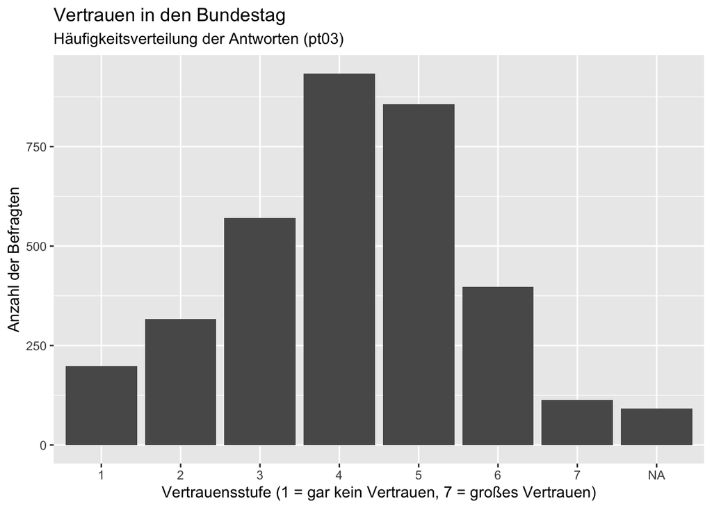

```r
ggplot(allbus, aes(x = as.factor(pt03))) +
  geom_bar() +
  labs(
    title = "Vertrauen in den Bundestag",
    subtitle = "Häufigkeitsverteilung der Antworten (pt03)",
    x = "Vertrauensstufe (1 = gar kein Vertrauen, 7 = großes Vertrauen)",
    y = "Anzahl der Befragten"
  )
```

```r
allbus$westost <- factor(allbus$eastwest, labels = c("Westdeutschland", "Ostdeutschland"))

allbus <- allbus %>%
  mutate(schulabschluss = case_when(educ == 2 ~ "Hauptschulabschluss",
                                    educ == 3 ~ "Mittlere Reife",
                                    educ %in% c(4,5) ~ "(Fach-)Abitur"))
```

```r
table(allbus$educ)
```

```
##
##    1    2    3    4    5    6    7
##   50  810 1195  302 1075   20   22
```

```r
table(allbus$schulabschluss)
```

```
##
##       (Fach-)Abitur Hauptschulabschluss      Mittlere Reife
##                1377                 810                1195
```

```r
tabelle <- table(allbus$westost, allbus$schulabschluss)
print(tabelle)
```

```
##
##                   (Fach-)Abitur Hauptschulabschluss Mittlere Reife
##   Westdeutschland          1020                 621            669
##   Ostdeutschland            357                 189            526
```

```r
tabelle_sum <- addmargins(tabelle) #summenwerte
print(tabelle_sum)
```

```
##
##                   (Fach-)Abitur Hauptschulabschluss Mittlere Reife  Sum
##   Westdeutschland          1020                 621            669 2310
##   Ostdeutschland            357                 189            526 1072
##   Sum                      1377                 810           1195 3382
```

```r
spaltenprozente <- round(100*prop.table(tabelle, 2),2)
spaltenprozente
```

```
##
##                   (Fach-)Abitur Hauptschulabschluss Mittlere Reife
##   Westdeutschland         74.07               76.67          55.98
##   Ostdeutschland          25.93               23.33          44.02
```

```r
install.packages("gmodels")
library(gmodels)
CrossTable(allbus$westost, allbus$schulabschluss, format="SPSS")
```

[output not shown]

```r
tabelle <- table(allbus$westost, allbus$schulabschluss)
chisq.test(tabelle)
```

```
##
##  Pearson's Chi-squared test
##
## data:  tabelle
## X-squared = 131.13, df = 2, p-value < 2.2e-16
```

```r
#install.packages("vcd")
library(vcd)
assocstats(tabelle)
```

```
##                     X^2 df P(> X^2)
## Likelihood Ratio 128.93  2        0
## Pearson          131.13  2        0
##
## Phi-Coefficient   : NA
## Contingency Coeff.: 0.193
## Cramer's V        : 0.197
```

```r
table(allbus$pt03, useNA = "ifany")
```

```
##
##    1    2    3    4    5    6    7 <NA>
##  198  316  570  934  857  398  113   91
```

```r
table(allbus$pt15, useNA = "ifany")
```

```
##
##    1    2    3    4    5    6    7 <NA>
##  260  488  868 1090  556  104   15   96
```

```r
table(allbus$pt03, allbus$pt15)
```

```
##
##       1   2   3   4   5   6   7
##   1 110  43  22  14   6   0   0
##   2  61 119  76  38  11   3   0
##   3  40 149 226 112  32   2   1
##   4  31 107 316 349 107  13   0
##   5   5  49 155 397 220  18   2
##   6   4  14  50 133 141  43   2
##   7   5   3   4  28  32  23   9
```

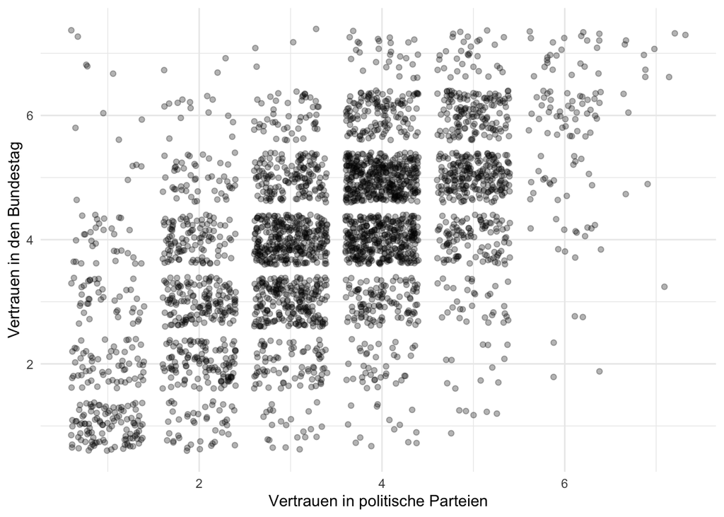

```r
ggplot(allbus, aes(x= pt15,
y = pt03)) +
geom_point(position = "jitter", alpha = 0.3) +
labs(x = "Vertrauen in politische Parteien",
y = "Vertrauen in den Bundestag") +
theme_minimal()
```

```r
cor.test(allbus$pt15,
allbus$pt03)
```

```
##
##  Pearson's product-moment correlation
##
## data:  allbus$pt15 and allbus$pt03
## t = 41.087, df = 3323, p-value < 2.2e-16
## alternative hypothesis: true correlation is not equal to 0
## 95 percent confidence interval:
##  0.5574159 0.6025157
## sample estimates:
##       cor
## 0.5804107
```

- **Stärke des Zusammenhangs:** Wie stark eine Variable mit der anderen Variable zusammenhängt, wird in der Höhe des Koefizienten angegeben. Je höher dieser Wert ist, desto stäker wird eine Variable durch die andere Variable bestimmt. Der Wert kann zwischen `0` und `+-1` liegen. Mit `0.58` ist der Zusammenhang zwischen den beiden Variablen hier relativ hoch.
- **Richtung des Zusammenhangs:** Hier kommt es auf das Vorzeichen des Koeffizienten an. Bei einem `+` sprechen wir von einem positiven Zusammenhang, während wir bei einem `-` von einem negativen Zusammenhang sprechen. In unserem Beispiel ist der Zusammenhang positiv: Je mehr eine Person in politische Parteien vertraut, **desto mehr** vertraut sie in den Bundestag. Wenn der Zusammenhang negativ wäre, würden wir die Richtung des Zusammenhangs so beschreiben: Je mehr eine Person in politische Parteien vertraut, **desto weniger** vertraut sie in den Bundestag.
- **Signifikanztest:** Hier wird überprüft, ob wir auch in der Grundgesamtheit von einem Zusammenhang zwischen den beiden Variablen ausgehen können. Wenn der `p-value` kleiner als `0.05` ist, können wir davon ausgehen, dass ein Zusammenhang zwischen den beiden Variablen auch in der Grundgesamtheit vorliegt. Dies ist in dem vorliegenden Beispiel gegeben.

Alles in allem scheint unsere Analyse die Hypothese, dass Personen, die politischen Parteien vertrauen, auch dem Bundestag vertrauen, Unterstützung in den Daten zu finden.

```r
 cor.test(allbus$pt15,
    allbus$pt03,
    method = "spearman")
```

```
##
##  Spearman's rank correlation rho
##
## data:  allbus$pt15 and allbus$pt03
## S = 2665385576, p-value < 2.2e-16
## alternative hypothesis: true rho is not equal to 0
## sample estimates:
##       rho
## 0.5649528
```

```r
 cor.test(allbus$pt15,
    allbus$pt03,
    method = "kendall")
```

```
##
##  Kendall's rank correlation tau
##
## data:  allbus$pt15 and allbus$pt03
## z = 34.649, p-value < 2.2e-16
## alternative hypothesis: true tau is not equal to 0
## sample estimates:
##       tau
## 0.4813628
```

```r
vertrauen <- allbus %>%
  select(pt03:pt15)

cor(vertrauen, use = "pairwise.complete.obs", method = "pearson")
```

```
##           pt03      pt04      pt08      pt09      pt10      pt11      pt12
## pt03 1.0000000 0.4018623 0.5418264 0.3695336 0.4158966 0.3527202 0.7012329
## pt04 0.4018623 1.0000000 0.3817825 0.2386091 0.2701777 0.3061913 0.3624219
## pt08 0.5418264 0.3817825 1.0000000 0.3040348 0.3622916 0.3919584 0.5107834
## pt09 0.3695336 0.2386091 0.3040348 1.0000000 0.6690724 0.2531800 0.3726665
## pt10 0.4158966 0.2701777 0.3622916 0.6690724 1.0000000 0.3842970 0.4094042
## pt11 0.3527202 0.3061913 0.3919584 0.2531800 0.3842970 1.0000000 0.3740649
## pt12 0.7012329 0.3624219 0.5107834 0.3726665 0.4094042 0.3740649 1.0000000
## pt14 0.3944567 0.3566765 0.5011352 0.2752920 0.3092543 0.4009544 0.4296461
## pt15 0.5804107 0.3369428 0.4364346 0.4198514 0.4473540 0.3089789 0.6366093
##           pt14      pt15
## pt03 0.3944567 0.5804107
## pt04 0.3566765 0.3369428
## pt08 0.5011352 0.4364346
## pt09 0.2752920 0.4198514
## pt10 0.3092543 0.4473540
## pt11 0.4009544 0.3089789
## pt12 0.4296461 0.6366093
## pt14 1.0000000 0.3888976
## pt15 0.3888976 1.0000000
```